# Topic Modelling of Medical Discussions

Lukas Huber  
March 2nd 2015

### Motivation

- natural language processing requires complex tools
- vast ammount of written text remains unanalyzed
- online boards share patients view on diseases
- Question: Can you find an structure within threads?
- Question: Is it possible to find new relations between diseases?

### Content

- Web Scraping
- Terms
- Topic Modeling
- Latent Dirichlet allocation
- Optimization of topics
- Data collection and preprocessing
- Demonstration

### Web Scraping

- Extracting information from Websites
- transformation of unstructured data (e.g. HTML)
- URL manipulation
- XPath to query XML

```r
head(xpathSApply(PARSED, "//span[@class='citation news']/a/@href"))
```

### Terms

- A *word* is the basic discrete unit from a *vocabulary* indexed {1,…,V}
- A *document* is a sequence of *N* words \( \mathbf{w} = (w_{1},w_{2},...,w_{n}) \)
- A *corpus* is a collection of *M* documents \( \mathbf{D}= (\mathbf{w_{1}},\mathbf{w_{2}},...,\mathbf{w_{m}}) \)

### Topic Modeling

[figure not shown]

romance (red) sarcasm (blue) math (black) language (green)

- statistical mixture model
- each document is a mixture of latent topics
- generative model, based on term frequencies
- bag-of-words models
- extend and build on
  - unigram models (McCallum, Thrun, Mitchell,…)
  - Latent Semantic analysis (Deerwester, Dumais, …)

### Latent Dirichlet allocation

- random variable \( w_i \) denotes the ith-token \( i \in \{1,...,N\} \)
- for vocabulary size \( v \in \{1,...,V\} \)
- probability of observing word \( i \) ind document \( d_i \): \( P(w_i = v) = \sum_{j=1}^T P(w_i = v | z_i = j)P(z_i = j) \)

where \( z_i \in \{1,...,T\} \) for a given number of topics *T*

- probability term-topic matrix \( \phi_i^{(j)} = P(w_i = v | z_i = j) \)
  - *V* by *T* where \( j^{th} \) column prob. dist. over words for topic *j*
- probability topic-document \( \theta_j^{(d_i)} = P(z_i = j) \)
  - *T* by *D* where \( d^{th} \) column contains topic prob. for document *d*

### Latent Dirichlet allocation cont.

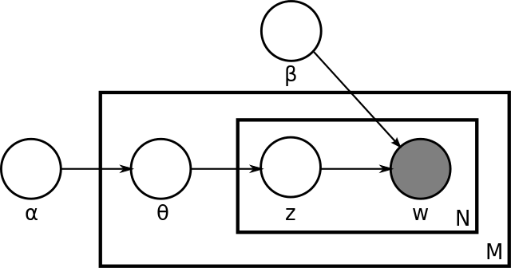

- \( \alpha \) is the parameter of the Dirichlet prior on the per-document topic distributions
- \( \beta \) is the parameter of the Dirichlet prior on the per-topic word distribution,
- \( \theta_i \) is the topic distribution for document *i*
- \( \phi_k \) is the word distribution for topic *k*
- \( z_{ij} \) is the topic for the \( j^{th} \) word in document *i*
- \( w_{ij} \) is the specific word

### Optimize number of topics

Given hyperparameters \( \alpha \) and \( \beta \) find optimal number of topics via Bayesian model selection

\( \max_T\{ p(T| \textbf{w}) \} = \max_T\{ p(\textbf{w}|T)p(T) \} \)

Using a uniform prior for \( p(T) \), we have \( \max_T p(w|T) \). Unfortunately, computing \( p(w|T) \) requires summing over all possible assignments of words to topics which is often unfeasible. Griffiths & Steyvers suggest approximating \( p(w|T) \) via a harmonic mean estimator:

\( p(w|T) \approx (\frac{1}{M} \sum^M_{m=1} p(\textbf{w} | \textbf{z}_m, T)^{-1})^{-1} \)

where \( \mathbf{z}_m \) is the \( m^{th} \) sample from the posterior \( p(\mathbf{z}|\mathbf{w}, T) \)

### Data collection and preprocessing

Acquire the documents from one thematic

```r
url <- "board.netdoktor.de"
thematics <- netDoktorScraper(url)
```

Get all documents and clear them

```r
docs <- getAllDocumentsofThematic(df.threads)
docs.cleared <- lapply(docs, clearNE)
```

Example scraping

```r
SOURCE <-  getURL(url,encoding="UTF-8")
PARSED <- htmlParse(SOURCE)
title <- xpathSApply(PARSED, "//span[contains(@itemprop,'itemListElement')]",xmlValue)
link <- xpathSApply(PARSED, "//span[contains(@itemprop, 'itemListElement')]/a/@href")
```

### Document term-matrice

```r
dtm.control <- list(
  tolower = T,
  removePunctuation = TRUE,
  removeNumbers = TRUE,
  stopwords = stopwords("de"),
  stemming = T,
  weighting = weightTf
)

corp <- VCorpus(VectorSource(docs.cleared))
dtm <- DocumentTermMatrix(corp, control = dtm.control)
dim(dtm)
dtm <- removeSparseTerms(dtm, 0.99)
dim(dtm)
```

### Model-generation

```r
### Parallel
library(parallel)
# Calculate the number of cores
no_cores <- detectCores() - 1

LDAt <- get("LDA")
# Initiate cluster
cl <- makeCluster(no_cores)
clusterExport(cl, "dtm.new") # Document term matrix
clusterExport(cl, "burnin") # burnin default 1000
clusterExport(cl, "iter") # iter default 1000
clusterExport(cl, "keep") # keep default 50
clusterExport(cl, "LDAt")
models <- parLapply(cl, ks, function(k) LDAt(dtm.new, k, method = "Gibbs", control = list(burnin = burnin, iter = iter, keep = keep)))

stopCluster(cl)
```

### Model-fitting

```r
logLiks <- lapply(models, function(L)  L@logLiks[-c(1:(burnin/keep))])
hm <- sapply(logLiks, function(h) harmonicMean(h))

plot(ks, hm, type = "l")
```

### Model-fitting

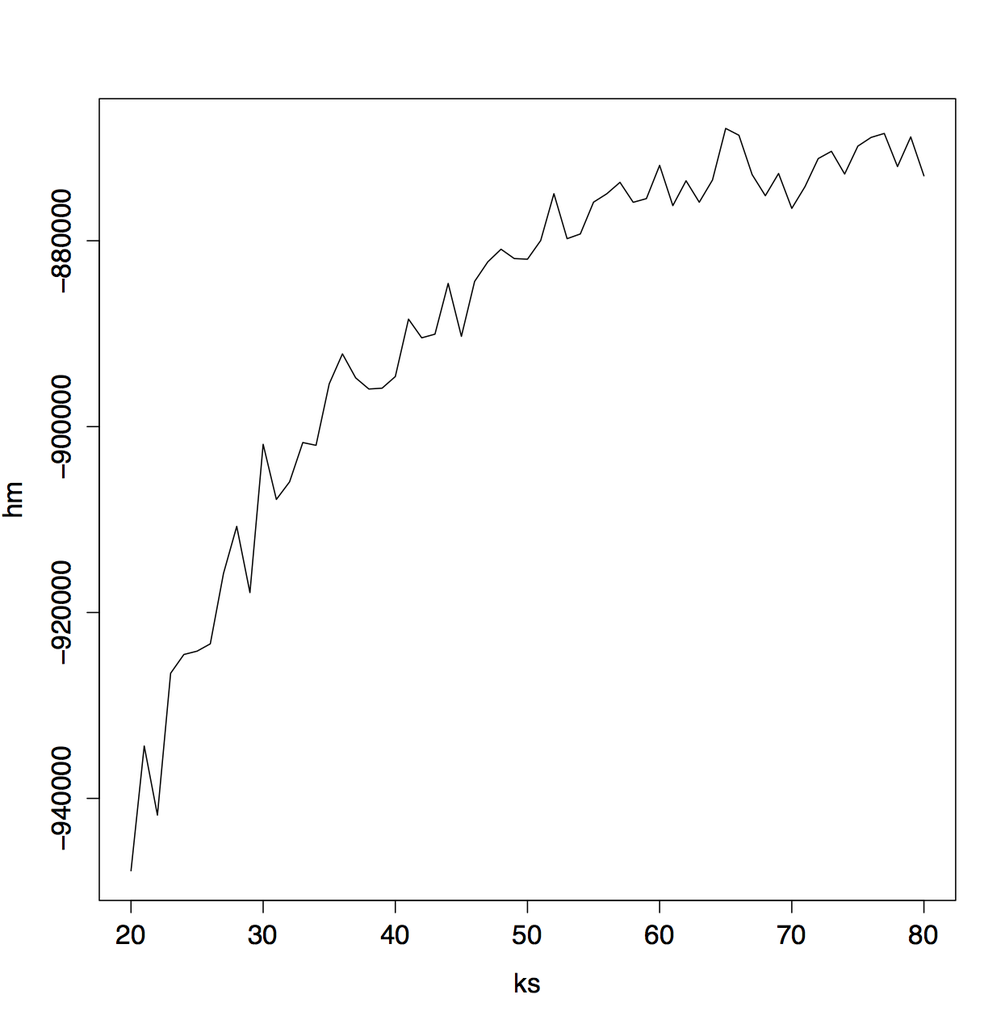

### Creating the visualisation

- phi: matrix, with each row containing the distribution over terms for a topic, with as many rows as there are topics in the model, and as many columns as there are terms in the vocabulary. |
- theta: matrix, with each row containing the probability distribution over topics for a document, with as many rows as there are documents in the corpus, and as many columns as there are topics in the model.
- doc.length: integer vector containing the number of tokens in each document of the corpus.
- vocab: character vector of the terms in the vocabulary (in the same order as the columns of phi). Each term must have at least one character.
- term.frequency: integer vector containing the frequency of each term in the vocabulary.
- lambda.step: a value between 0 and 1. Determines the interstep distance in the grid of lambda values over which to iterate when computing relevance. Default is 0.01. Recommended to be between 0.01 and 0.1.
- mds.method: a function that takes phi as an input and outputs a K by 2 data.frame (or matrix). The output approximates the distance between topics. See jsPCA for details on the default method.

### Final Product

```r
library(LDAvis)
load("lda.Rdata")
serVis(json, out.dir="nurs_lda", open.browser = T)
```

### Discussion

- extend the list of stop words
- better stemming algorithm
- create a document per entry not per thread and hold the relations.
- Correlated topic model
- Pachinko allocation (Blei et. al.) to cover longer terms (e.g. right eye)
- use the relations between threads and connect them on the person
- use time information to analyze trends or weather conditions
- OpenCL acceleration
- …

### References and further reading

- Rolf Fredheim, Web Scraping http://quantifyingmemory.blogspot.co.uk/2014/02/web-scraping-basics.html
- C.P. Sievert, XCKD Topic Modeling https://cpsievert.github.io/projects/615/xkcd/
- See my Seminarwork for full Bibliography